# IE582 Homework 1: Antenna Design Analysis

Burcu Çeştan - 2023702012

2024-11-4

## 1. Introduction

This report explores the impact of antenna design parameters on the S11 behavior using Principal Component Analysis (PCA) for dimensionality reduction and linear regression modeling for prediction. Given the complexity and computational cost of traditional electromagnetic simulations, machine learning provides an efficient way to model the relationship between design parameters and antenna performance. The goal is to identify key design parameters and simplify the regression task by predicting S11 at specific frequency points.

## 2. Data Overview

The data includes design parameters and S11 real and imaginary parts, which are essential for analyzing the antenna’s performance across different frequency points.

The datasets used in this analysis include:

- **Design Parameters**: 11 variables representing various characteristics of the antenna’s geometry and material properties.
- **Real Part of S11**: The real component of the S11 parameter, measured across multiple frequency points, used to evaluate the antenna’s performance in terms of power reflection.
- **Imaginary Part of S11**: The imaginary component of the S11 parameter, corresponding to the reactive part of the impedance, also measured across the same frequency points to assess the antenna’s behavior in the frequency domain.

```r
# Load necessary libraries

library(readr)
library(dplyr)
library(ggplot2)
library(FactoMineR)
library(factoextra)
library(tidyverse)
library(caret)
```

```r
input_data <- read_csv("/Users/burcucestan/Desktop/HW1/hw1_files/hw1_input.csv", show_col_types = FALSE)
real_s11 <- read_csv("/Users/burcucestan/Desktop/HW1/hw1_files/hw1_real.csv" , show_col_types = FALSE)
img_s11 <- read_csv("/Users/burcucestan/Desktop/HW1/hw1_files/hw1_img.csv", show_col_types = FALSE)

#combine the data
suppressMessages({
  data <- bind_cols(input_data, real_s11, img_s11)
})
```

## 3. Methodology

### 3.1. PCA Application

```r
# Ensure all variables are on the same scale before performing PCA.
standardized_data <- scale(data)

# The mean and standard deviation of each variable were checked after standardization to confirm that all variables have a mean close to 0 and a standard deviation close to 1. This ensures that no single variable dominates the PCA due to scale differences.

#apply(standardized_data, 2, mean) -- I commented them since this is too long
#apply(standardized_data, 2, sd)

# Conduct PCA on the standardized data to identify main components.
pca_analysis <- prcomp(standardized_data, center = TRUE, scale. = TRUE)


# Display a summary of PCA
# The summary shows the variance explained by each principal component.
summary(pca_analysis)
```

```
## Importance of components:
##                            PC1    PC2    PC3     PC4     PC5     PC6     PC7
## Standard deviation     14.6600 7.6774 6.7632 6.31034 4.55034 3.13688 2.18561
## Proportion of Variance  0.5204 0.1427 0.1108 0.09642 0.05013 0.02383 0.01157
## Cumulative Proportion   0.5204 0.6631 0.7739 0.87027 0.92040 0.94423 0.95579
##                            PC8     PC9    PC10    PC11    PC12    PC13    PC14
## Standard deviation     1.80568 1.41121 1.24671 1.07842 1.04027 1.00766 0.98350
## Proportion of Variance 0.00789 0.00482 0.00376 0.00282 0.00262 0.00246 0.00234
## Cumulative Proportion  0.96369 0.96851 0.97227 0.97509 0.97771 0.98017 0.98251
##                           PC15    PC16    PC17    PC18    PC19    PC20   PC21
## Standard deviation     0.97606 0.96003 0.92239 0.88165 0.83210 0.79363 0.7333
## Proportion of Variance 0.00231 0.00223 0.00206 0.00188 0.00168 0.00153 0.0013
## Cumulative Proportion  0.98482 0.98705 0.98911 0.99099 0.99267 0.99419 0.9955
##                           PC22    PC23    PC24    PC25    PC26    PC27    PC28
## Standard deviation     0.63324 0.58020 0.46977 0.42080 0.33982 0.32301 0.30157
## Proportion of Variance 0.00097 0.00082 0.00053 0.00043 0.00028 0.00025 0.00022
## Cumulative Proportion  0.99646 0.99728 0.99781 0.99824 0.99852 0.99877 0.99899
##                           PC29    PC30    PC31    PC32    PC33    PC34    PC35
## Standard deviation     0.27134 0.26676 0.22639 0.21309 0.18020 0.16991 0.13855
## Proportion of Variance 0.00018 0.00017 0.00012 0.00011 0.00008 0.00007 0.00005
## Cumulative Proportion  0.99917 0.99935 0.99947 0.99958 0.99966 0.99973 0.99977
##                           PC36    PC37    PC38    PC39    PC40    PC41    PC42
## Standard deviation     0.11671 0.10926 0.10269 0.09887 0.08470 0.08173 0.07875
## Proportion of Variance 0.00003 0.00003 0.00003 0.00002 0.00002 0.00002 0.00002
## Cumulative Proportion  0.99981 0.99984 0.99986 0.99989 0.99990 0.99992 0.99993
##                           PC43    PC44    PC45    PC46    PC47    PC48    PC49
## Standard deviation     0.07664 0.06823 0.06278 0.04815 0.04702 0.04024 0.03785
## Proportion of Variance 0.00001 0.00001 0.00001 0.00001 0.00001 0.00000 0.00000
## Cumulative Proportion  0.99995 0.99996 0.99997 0.99997 0.99998 0.99998 0.99999
##                           PC50    PC51    PC52    PC53    PC54    PC55    PC56
## Standard deviation     0.02997 0.02778 0.02457 0.02276 0.02198 0.01943 0.01837
## Proportion of Variance 0.00000 0.00000 0.00000 0.00000 0.00000 0.00000 0.00000
## Cumulative Proportion  0.99999 0.99999 0.99999 0.99999 1.00000 1.00000 1.00000
##                           PC57    PC58    PC59    PC60     PC61     PC62
## Standard deviation     0.01625 0.01572 0.01333 0.01122 0.009855 0.008649
## Proportion of Variance 0.00000 0.00000 0.00000 0.00000 0.000000 0.000000
## Cumulative Proportion  1.00000 1.00000 1.00000 1.00000 1.000000 1.000000
##                            PC63     PC64     PC65     PC66     PC67     PC68
## Standard deviation     0.008493 0.007298 0.006406 0.005295 0.004847 0.004309
## Proportion of Variance 0.000000 0.000000 0.000000 0.000000 0.000000 0.000000
```

[output cut: 218 more lines]

[output not shown]

```r
#We are selecting the first four components (PC1, PC2, PC3, and PC4) because together they explain approximately 87.03% of the total variance in the data.

# Create a data frame for individual variance and cumulative variance
variance <- data.frame(
  Component = paste0("PC", 1:4),
  Variance_Ratio = (summary(pca_analysis)$importance[2, 1:4]),
  Cumulative_Ratio = cumsum(summary(pca_analysis)$importance[2, 1:4])
)


print(variance)
```

```
##     Component Variance_Ratio Cumulative_Ratio
## PC1       PC1        0.52038          0.52038
## PC2       PC2        0.14272          0.66310
## PC3       PC3        0.11075          0.77385
## PC4       PC4        0.09642          0.87027
```

```r
# Display the loadings of each parameter to the first 4 principal components
loadings <- pca_analysis$rotation[1:11, 1:4]
loadings_df <- as.data.frame(loadings)
rownames(loadings_df) <- colnames(data)[1:11]
colnames(loadings_df) <- paste0("PC", 1:4)

print(loadings_df)
```

```
##                                                      PC1           PC2
## length of patch                             4.893667e-03  0.0123047928
## width of patch                             -5.976961e-02  0.0138787860
## height of patch                            -4.229619e-03  0.0085780354
## height of substrate                        -6.443185e-02  0.0029839547
## height of solder resist layer               1.096583e-03  0.0034607322
## radius of the probe                        -3.095694e-03 -0.0282805290
## c_pad                                       3.418793e-03 -0.0006556469
## c_antipad                                   4.742879e-03  0.0158598277
## c_probe                                    -1.187254e-02 -0.0261847293
## dielectric constant of substrate           -2.734790e-02  0.0097524037
## dielectric constant of solder resist layer  1.739059e-05  0.0137782306
##                                                     PC3          PC4
## length of patch                            -0.005707485  0.023667221
## width of patch                              0.036498759 -0.016269983
## height of patch                             0.010962145 -0.010263190
## height of substrate                         0.030201881 -0.006116180
## height of solder resist layer               0.003279152  0.012030716
## radius of the probe                        -0.021399563  0.027511767
## c_pad                                      -0.003929980 -0.003314531
## c_antipad                                   0.012940520 -0.004372790
## c_probe                                    -0.037344225  0.024710639
## dielectric constant of substrate            0.036839027  0.010112438
## dielectric constant of solder resist layer  0.004028954 -0.005313072
```

```r
# The loadings indicate the contribution of each design parameter to the principal components. High loadings suggest that specific parameters play a more significant role in that component's variance, offering insights into which features are most relevant for the antenna's electromagnetic behavior.
```

## Answers to Research Questions

#### Can we reduce the complexity of the design space using PCA?

Yes, PCA can help reduce the complexity of the design space by transforming the original parameters into a smaller set of principal components. These components capture the maximum variance within the data, meaning they represent the most significant patterns or relationships. By analyzing the loadings (contributions of each original parameter to the principal components), we can identify which parameters most influence the variance, potentially highlighting those that most impact the S11 response. Here, by selecting the first four principal components, we capture approximately 87% of the total variance. This indicates that we can significantly reduce the complexity of the design space while retaining a substantial amount of the information, making the analysis and modeling more manageable.

#### How much of the total variance is explained by the principal components?

The total variance explained by the principal components is given by the cumulative variance ratio of the selected principal components. Based on our choice of the first four principal components, which cumulatively explain around 87% of the total variance (from the PCA results), this means that these four components effectively represent the majority of the information in the original parameter space.

#### What insights can we draw from the PCA regarding the relationship between geometry and electromagnetic behavior?

The loadings suggest that particular geometric and material parameters, such as “height of substrate,” “dielectric constant of substrate,” “width of patch,” and “length of patch,” are key contributors to the variance captured by the principal components (PC1 to PC4).

**PC1** In PC1, the most influential factors are “width of patch” (-0.0598) and “height of substrate” (-0.0644), which exhibit the highest loadings. Additionally, “dielectric constant of substrate” (-0.0273) moderately impacts this component, indicating that substrate properties are integral to the primary variance pattern. Conversely, “length of patch” and “height of patch” have minimal impact on PC1, as their loadings are close to zero.

**PC2** The parameters with the strongest influence on PC2 are “radius of the probe” (-0.0283) and “c_probe” (-0.0262), suggesting that this component is primarily shaped by probe-related aspects. The contributions of “width of patch” (0.0139) and “dielectric constant of substrate” (0.0098) are lower, indicating that geometric and material factors play a secondary role in this variance pattern.

**PC3** In PC3, the largest contributors are “c_probe” (-0.0373), “dielectric constant of substrate” (0.0368), “width of patch” (0.0365), and “height of substrate” (0.0302). The presence of both positive and negative loadings implies opposing influences, where certain parameters offset the effects of others. This suggests a complex interaction, particularly between probe capacitance and substrate properties.

**PC4** For PC4, the main contributors are “radius of the probe” (0.0275), “length of patch” (0.0236), and “c_probe” (0.0247). This component appears to be driven by both probe characteristics and specific geometric dimensions.

In summary, modifying these key parameters—particularly those that dominate the loadings for each principal component—could meaningfully impact the antenna’s performance, especially with respect to optimizing the s11 response.

### 3.2. Frequency Selection

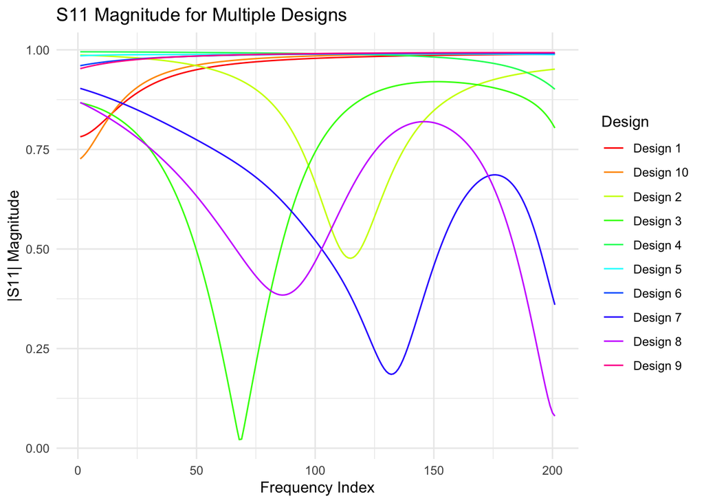

```r
# Lower magnitude values indicate less signal loss, meaning the antenna operates efficiently at that frequency.
# Therefore, we calculate the magnitude to identify the resonance frequencies (minimum points of |S11|).

# Specify the number of designs to plot
num_designs <- 10  # Set this to the desired number of designs

# Calculate the magnitude of S11 (|S11|)
magnitude_s11 <- sqrt(real_s11^2 + img_s11^2)

# Create a combined data frame for plotting multiple designs in one plot
plot_data <- data.frame(
  Frequency = rep(1:ncol(magnitude_s11), times = num_designs),  # Repeat frequency index for each design
  Magnitude = as.vector(t(magnitude_s11[1:num_designs, ])),  # Stack magnitude values for the selected designs
  Design = rep(paste("Design", 1:num_designs), each = ncol(magnitude_s11))  # Label each design
)

# Plot using ggplot2 with different colors for each design
library(ggplot2)

ggplot(plot_data, aes(x = Frequency, y = Magnitude, color = Design)) +
  geom_line() +
  labs(title = "S11 Magnitude for Multiple Designs",
       x = "Frequency Index",
       y = "|S11| Magnitude") +
  theme_minimal() +
  scale_color_manual(values = rainbow(num_designs))  # Use rainbow colors for a range of colors
```

```r
# Initialize a vector to store minimum indices for each design
min_indices <- integer()

# Loop through each design to find the index of the minimum |S11| magnitude
for (i in 1:nrow(magnitude_s11)) {
  min_index <- which.min(magnitude_s11[i, ])  # Find the index of the minimum value for each design
  min_indices <- c(min_indices, min_index)  # Append the result to the vector
}

print(min_indices)
```

```
##   0 114  67 200   0   0 131 200   0   0  96   0  10   0  93 148  28   0  41   0
##   1 115  68 201   1   1 132 201   1   1  97   1  11   1  94 149  29   1  42   1
## 129  38 104  98 188  77  27   0  58 187 200   0  97 200   0   0   3 200 200 149
## 130  39 105  99 189  78  28   1  59 188 201   1  98 201   1   1   4 201 201 150
## 103   4 137  76 170   0 120 200   1  85 151   0  34 200   0   0   0 144 168 118
## 104   5 138  77 171   1 121 201   2  86 152   1  35 201   1   1   1 145 169 119
## 200 145 159 106 159 200  54 121 148 200  74 200 164 114  32 117 114 138  61 200
## 201 146 160 107 160 201  55 122 149 201  75 201 165 115  33 118 115 139  62 201
##  34  63 131  88 200 106 200 138 131 108 200 200  85 200  96 200 200   0 176 200
##  35  64 132  89 201 107 201 139 132 109 201 201  86 201  97 201 201   1 177 201
## 108 200   0  78 200 200  78 200 140 104 200 172 200   0  65 137 133 187 105 200
## 109 201   1  79 201 201  79 201 141 105 201 173 201   1  66 138 134 188 106 201
## 104   0  92 200   5 200   0 138  78 155 105   0 154 200 140   0  61  72  71   0
## 105   1  93 201   6 201   1 139  79 156 106   1 155 201 141   1  62  73  72   1
## 200 145 200 188 127  53   0 200 165 200 200 114   0   0 152   0 165 132   0 198
```

[output cut: 25 more lines]

```r
# Count the frequency of each minimum index to find common minimum points
min_index_counts <- table(min_indices)
print(min_index_counts)  # Print frequency of minimum points across designs
```

```
## min_indices
##   1   2   4   5   6   9  10  11  15  16  20  22  24  28  29  32  33  35  39  40
##  63   1   2   1   1   1   1   1   2   2   1   1   2   1   1   1   1   2   1   2
##  41  42  43  45  46  47  49  50  51  54  55  56  57  59  60  62  63  64  65  66
##   1   1   2   1   1   2   2   1   1   1   1   1   1   1   1   4   2   1   1   1
##  67  68  69  71  72  73  74  75  76  77  78  79  81  86  87  88  89  91  93  94
##   2   1   1   2   3   2   1   2   2   2   3   3   1   2   2   3   3   1   1   3
##  95  96  97  98  99 102 104 105 106 107 109 110 111 112 113 114 115 116 118 119
##   2   5   2   2   2   1   2   3   3   4   2   1   1   3   2   1   6   2   2   1
## 121 122 125 127 128 130 131 132 133 134 135 136 138 139 141 142 143 144 145 146
##   1   2   3   1   3   2   3   3   1   3   4   3   2   3   2   1   1   1   2   3
## 147 148 149 150 152 153 154 155 156 157 160 161 162 165 166 168 169 170 171 173
##   1   2   4   1   1   2   2   2   2   1   2   1   1   2   2   2   2   1   2   2
## 174 176 177 178 180 182 183 184 185 186 188 189 190 193 198 199 201
##   1   1   3   2   1   1   1   3   1   2   2   2   1   2   2   2  77
```

```r
# Select the most common minimum indices
selected_indices <- as.numeric(names(min_index_counts)[min_index_counts >= 3])  # Select indices appearing in multiple designs
print(selected_indices)
```

```
##  [1]   1  62  72  78  79  88  89  94  96 105 106 107 112 115 125 128 131 132 134
## [20] 135 136 139 146 149 177 184 201
```

Five frequency points (62, 88, 105, 132, 177) were chosen based on the following criteria:

**Frequent Minimum Values:** These points showed minimum S11 magnitudes across multiple designs, indicating resonance frequencies where the antenna performs most efficiently. **Coverage Across Frequency Range:** Points were selected from low (62), mid (88 and 105), and high (132 and 177) frequency ranges to capture overall performance. **Distinctive Behavior:** These frequencies exhibit clear minimum points in S11, helping the model focus on critical performance frequencies. This selection balances model efficiency with meaningful frequency representation.

### 3.3. Regression Modeling for S11

# Regression for frequency at 62

```r
# Define the selected frequency indices
selected_indices <- c(62, 88, 105, 132, 177)


# model the all selected frequencies
freq_index <- 62
real_selected <- as.numeric(real_s11[[freq_index]])  # Real component
img_selected <- as.numeric(img_s11[[freq_index]])    # Imaginary component

# Tüm 11 geometrik parametre ile modelleme
linear_model_real <- lm(real_selected ~ ., data = input_data)
linear_model_img <- lm(img_selected ~ ., data = input_data)

# print the results
summary(linear_model_real)
```

```
##
## Call:
## lm(formula = real_selected ~ ., data = input_data)
##
## Residuals:
##      Min       1Q   Median       3Q      Max
## -0.73685 -0.18278 -0.06879  0.12954  1.21306
##
## Coefficients:
##                                               Estimate Std. Error t value
## (Intercept)                                  -0.949091   0.161618  -5.872
## `length of patch`                            -0.016000   0.015914  -1.005
## `width of patch`                              0.110592   0.033964   3.256
## `height of patch`                            -0.082291   1.734987  -0.047
## `height of substrate`                         1.846971   0.147831  12.494
## `height of solder resist layer`              -0.660653   0.639330  -1.033
## `radius of the probe`                        -3.593734   1.466229  -2.451
## c_pad                                        -0.310560   2.131386  -0.146
## c_antipad                                    -0.837400   0.711834  -1.176
## c_probe                                       0.392598   0.137791   2.849
## `dielectric constant of substrate`           -0.054701   0.020080  -2.724
## `dielectric constant of solder resist layer`  0.005727   0.017501   0.327
##                                              Pr(>|t|)
## (Intercept)                                  9.51e-09 ***
## `length of patch`                             0.31536
## `width of patch`                              0.00123 **
## `height of patch`                             0.96220
## `height of substrate`                         < 2e-16 ***
## `height of solder resist layer`               0.30211
## `radius of the probe`                         0.01470 *
## c_pad                                         0.88423
## c_antipad                                     0.24019
## c_probe                                       0.00463 **
## `dielectric constant of substrate`            0.00675 **
## `dielectric constant of solder resist layer`  0.74366
## ---
## Signif. codes:  0 '***' 0.001 '**' 0.01 '*' 0.05 '.' 0.1 ' ' 1
##
## Residual standard error: 0.2956 on 373 degrees of freedom
## Multiple R-squared:  0.8152, Adjusted R-squared:  0.8098
## F-statistic: 149.6 on 11 and 373 DF,  p-value: < 2.2e-16
```

```r
summary(linear_model_img)
```

```
##
## Call:
## lm(formula = img_selected ~ ., data = input_data)
##
## Residuals:
##      Min       1Q   Median       3Q      Max
## -1.05079 -0.11537  0.03323  0.16806  0.74906
##
## Coefficients:
##                                              Estimate Std. Error t value
## (Intercept)                                   0.05372    0.16248   0.331
## `length of patch`                             0.04297    0.01600   2.686
## `width of patch`                              0.07706    0.03414   2.257
## `height of patch`                             1.80206    1.74422   1.033
## `height of substrate`                        -0.85884    0.14862  -5.779
## `height of solder resist layer`               0.51161    0.64273   0.796
## `radius of the probe`                        -4.97609    1.47403  -3.376
## c_pad                                         1.00214    2.14272   0.468
## c_antipad                                     1.37316    0.71562   1.919
## c_probe                                      -0.56112    0.13852  -4.051
## `dielectric constant of substrate`            0.02272    0.02019   1.125
## `dielectric constant of solder resist layer`  0.03031    0.01759   1.723
##                                              Pr(>|t|)
## (Intercept)                                  0.741132
## `length of patch`                            0.007560 **
## `width of patch`                             0.024595 *
## `height of patch`                            0.302197
## `height of substrate`                        1.59e-08 ***
## `height of solder resist layer`              0.426538
## `radius of the probe`                        0.000813 ***
## c_pad                                        0.640277
## c_antipad                                    0.055768 .
## c_probe                                      6.22e-05 ***
## `dielectric constant of substrate`           0.261156
## `dielectric constant of solder resist layer` 0.085806 .
## ---
## Signif. codes:  0 '***' 0.001 '**' 0.01 '*' 0.05 '.' 0.1 ' ' 1
##
## Residual standard error: 0.2972 on 373 degrees of freedom
## Multiple R-squared:  0.2826, Adjusted R-squared:  0.2614
## F-statistic: 13.36 on 11 and 373 DF,  p-value: < 2.2e-16
```

The regression model for frequency 62 shows a strong fit for the real component with an adjusted R-squared of 0.81, explaining 81% of the variance. Significant predictors include height of substrate (positive impact), width of patch (positive), radius of the probe (negative), and dielectric constant of substrate (negative). For the imaginary component, the model fit is weaker, with an adjusted R-squared of 0.26, indicating that it explains only 26% of the variance. Key predictors here are height of substrate (negative impact), length and width of patch (positive), radius of the probe (negative). Both models are statistically significant (p-value < 2.2e-16).

# Regression for frequency at 88

```r
#frequency= 88
freq_index <- 88
real_selected <- as.numeric(real_s11[[freq_index]])
img_selected <- as.numeric(img_s11[[freq_index]])


linear_model_real <- lm(real_selected ~ ., data = input_data)
linear_model_img <- lm(img_selected ~ ., data = input_data)


summary(linear_model_real)
```

```
##
## Call:
## lm(formula = real_selected ~ ., data = input_data)
##
## Residuals:
##      Min       1Q   Median       3Q      Max
## -0.70692 -0.16945 -0.04764  0.10274  1.54642
##
## Coefficients:
##                                              Estimate Std. Error t value
## (Intercept)                                  -0.96768    0.16837  -5.747
## `length of patch`                             0.00322    0.01658   0.194
## `width of patch`                              0.06341    0.03538   1.792
## `height of patch`                            -0.34491    1.80751  -0.191
## `height of substrate`                         1.92556    0.15401  12.503
## `height of solder resist layer`              -0.25850    0.66605  -0.388
## `radius of the probe`                        -3.95804    1.52751  -2.591
## c_pad                                        -2.05480    2.22047  -0.925
## c_antipad                                    -0.48116    0.74159  -0.649
## c_probe                                       0.40954    0.14355   2.853
## `dielectric constant of substrate`           -0.05468    0.02092  -2.614
## `dielectric constant of solder resist layer`  0.02039    0.01823   1.118
##                                              Pr(>|t|)
## (Intercept)                                  1.89e-08 ***
## `length of patch`                             0.84613
## `width of patch`                              0.07394 .
## `height of patch`                             0.84877
## `height of substrate`                         < 2e-16 ***
## `height of solder resist layer`               0.69815
## `radius of the probe`                         0.00994 **
## c_pad                                         0.35536
## c_antipad                                     0.51685
## c_probe                                       0.00457 **
## `dielectric constant of substrate`            0.00931 **
## `dielectric constant of solder resist layer`  0.26425
## ---
## Signif. codes:  0 '***' 0.001 '**' 0.01 '*' 0.05 '.' 0.1 ' ' 1
##
## Residual standard error: 0.308 on 373 degrees of freedom
## Multiple R-squared:  0.785,  Adjusted R-squared:  0.7787
## F-statistic: 123.8 on 11 and 373 DF,  p-value: < 2.2e-16
```

```r
summary(linear_model_img)
```

```
##
## Call:
## lm(formula = img_selected ~ ., data = input_data)
##
## Residuals:
##      Min       1Q   Median       3Q      Max
## -1.03342 -0.14199  0.01663  0.17427  0.71763
##
## Coefficients:
##                                              Estimate Std. Error t value
## (Intercept)                                  -0.04842    0.15186  -0.319
## `length of patch`                             0.05090    0.01495   3.404
## `width of patch`                              0.08792    0.03191   2.755
## `height of patch`                             2.13536    1.63019   1.310
## `height of substrate`                        -0.96664    0.13890  -6.959
## `height of solder resist layer`               0.76338    0.60071   1.271
## `radius of the probe`                        -4.22708    1.37767  -3.068
## c_pad                                        -0.46986    2.00265  -0.235
## c_antipad                                     1.18614    0.66884   1.773
## c_probe                                      -0.59070    0.12947  -4.562
## `dielectric constant of substrate`            0.06378    0.01887   3.381
## `dielectric constant of solder resist layer`  0.01478    0.01644   0.899
##                                              Pr(>|t|)
## (Intercept)                                  0.750004
## `length of patch`                            0.000736 ***
## `width of patch`                             0.006157 **
## `height of patch`                            0.191043
## `height of substrate`                        1.55e-11 ***
## `height of solder resist layer`              0.204595
## `radius of the probe`                        0.002310 **
## c_pad                                        0.814635
## c_antipad                                    0.076974 .
## c_probe                                      6.87e-06 ***
## `dielectric constant of substrate`           0.000800 ***
## `dielectric constant of solder resist layer` 0.369293
## ---
## Signif. codes:  0 '***' 0.001 '**' 0.01 '*' 0.05 '.' 0.1 ' ' 1
##
## Residual standard error: 0.2778 on 373 degrees of freedom
## Multiple R-squared:  0.3254, Adjusted R-squared:  0.3055
## F-statistic: 16.35 on 11 and 373 DF,  p-value: < 2.2e-16
```

The regression model for frequency 88 demonstrates a strong fit for the real component with an adjusted R-squared of 0.7787, explaining around 78% of the variance. Significant predictors include height of substrate (positive impact), radius of the probe (negative), c_probe (positive), and dielectric constant of substrate (negative). For the imaginary component, the model fit is weaker, with an adjusted R-squared of 0.3055, indicating that it explains about 30% of the variance. Key predictors here are height of substrate (negative impact), length of patch (positive), width of patch (positive), radius of the probe (negative), and c_probe (negative). Both models are statistically significant (p-value < 2.2e-16).

# Regression for frequency at 105

```r
#frequency= 105
freq_index <- 105
real_selected <- as.numeric(real_s11[[freq_index]])
img_selected <- as.numeric(img_s11[[freq_index]])


linear_model_real <- lm(real_selected ~ ., data = input_data)
linear_model_img <- lm(img_selected ~ ., data = input_data)


summary(linear_model_real)
```

```
##
## Call:
## lm(formula = real_selected ~ ., data = input_data)
##
## Residuals:
##      Min       1Q   Median       3Q      Max
## -0.65255 -0.17473 -0.03435  0.12661  1.49168
##
## Coefficients:
##                                              Estimate Std. Error t value
## (Intercept)                                  -1.27413    0.16512  -7.716
## `length of patch`                             0.02331    0.01626   1.434
## `width of patch`                              0.08441    0.03470   2.432
## `height of patch`                            -0.32959    1.77262  -0.186
## `height of substrate`                         1.75553    0.15104  11.623
## `height of solder resist layer`               0.12939    0.65320   0.198
## `radius of the probe`                        -3.32906    1.49803  -2.222
## c_pad                                        -0.36581    2.17762  -0.168
## c_antipad                                    -0.31599    0.72727  -0.434
## c_probe                                       0.40829    0.14078   2.900
## `dielectric constant of substrate`           -0.02238    0.02052  -1.091
## `dielectric constant of solder resist layer`  0.02637    0.01788   1.475
##                                              Pr(>|t|)
## (Intercept)                                  1.11e-13 ***
## `length of patch`                             0.15242
## `width of patch`                              0.01547 *
## `height of patch`                             0.85260
## `height of substrate`                         < 2e-16 ***
## `height of solder resist layer`               0.84309
## `radius of the probe`                         0.02686 *
## c_pad                                         0.86669
## c_antipad                                     0.66419
## c_probe                                       0.00395 **
## `dielectric constant of substrate`            0.27593
## `dielectric constant of solder resist layer`  0.14116
## ---
## Signif. codes:  0 '***' 0.001 '**' 0.01 '*' 0.05 '.' 0.1 ' ' 1
##
## Residual standard error: 0.3021 on 373 degrees of freedom
## Multiple R-squared:  0.784,  Adjusted R-squared:  0.7776
## F-statistic: 123.1 on 11 and 373 DF,  p-value: < 2.2e-16
```

```r
summary(linear_model_img)
```

```
##
## Call:
## lm(formula = img_selected ~ ., data = input_data)
##
## Residuals:
##      Min       1Q   Median       3Q      Max
## -1.04930 -0.15650  0.01828  0.18005  0.76210
##
## Coefficients:
##                                               Estimate Std. Error t value
## (Intercept)                                  -0.141537   0.152569  -0.928
## `length of patch`                             0.044857   0.015023   2.986
## `width of patch`                              0.116569   0.032062   3.636
## `height of patch`                             2.345559   1.637841   1.432
## `height of substrate`                        -1.112011   0.139553  -7.968
## `height of solder resist layer`               0.953303   0.603532   1.580
## `radius of the probe`                        -3.734331   1.384131  -2.698
## c_pad                                         0.976731   2.012044   0.485
## c_antipad                                     1.427799   0.671977   2.125
## c_probe                                      -0.710097   0.130076  -5.459
## `dielectric constant of substrate`            0.085066   0.018955   4.488
## `dielectric constant of solder resist layer`  0.007299   0.016521   0.442
##                                              Pr(>|t|)
## (Intercept)                                  0.354168
## `length of patch`                            0.003013 **
## `width of patch`                             0.000316 ***
## `height of patch`                            0.152951
## `height of substrate`                        1.97e-14 ***
## `height of solder resist layer`              0.115060
## `radius of the probe`                        0.007293 **
## c_pad                                        0.627648
## c_antipad                                    0.034262 *
## c_probe                                      8.75e-08 ***
## `dielectric constant of substrate`           9.60e-06 ***
## `dielectric constant of solder resist layer` 0.658872
## ---
## Signif. codes:  0 '***' 0.001 '**' 0.01 '*' 0.05 '.' 0.1 ' ' 1
##
## Residual standard error: 0.2791 on 373 degrees of freedom
## Multiple R-squared:   0.35,  Adjusted R-squared:  0.3308
## F-statistic: 18.26 on 11 and 373 DF,  p-value: < 2.2e-16
```

The regression model for frequency 105 shows a strong fit for the real component with an adjusted R-squared of 0.7776, explaining around 78% of the variance. Significant predictors include height of substrate (positive impact), width of patch (positive), radius of the probe (negative), and probe capacitance (c_probe) (positive). For the imaginary component, the model fit is weaker, with an adjusted R-squared of 0.3308, indicating it explains about 33% of the variance. Key predictors here are height of substrate (negative impact), width of patch (positive), radius of the probe (negative), probe capacitance (c_probe) (negative), and dielectric constant of substrate (positive). Both models are statistically significant (p-value < 2.2e-16).

# Regression for frequency at 132

```r
#frequency= 132
freq_index <- 132
real_selected <- as.numeric(real_s11[[freq_index]])
img_selected <- as.numeric(img_s11[[freq_index]])


linear_model_real <- lm(real_selected ~ ., data = input_data)
linear_model_img <- lm(img_selected ~ ., data = input_data)


summary(linear_model_real)
```

```
##
## Call:
## lm(formula = real_selected ~ ., data = input_data)
##
## Residuals:
##      Min       1Q   Median       3Q      Max
## -0.69204 -0.17084 -0.05181  0.10579  1.30027
##
## Coefficients:
##                                               Estimate Std. Error t value
## (Intercept)                                  -1.660383   0.156288 -10.624
## `length of patch`                             0.049612   0.015389   3.224
## `width of patch`                              0.110472   0.032844   3.364
## `height of patch`                             0.692296   1.677766   0.413
## `height of substrate`                         1.523016   0.142955  10.654
## `height of solder resist layer`               0.901886   0.618244   1.459
## `radius of the probe`                        -1.966665   1.417872  -1.387
## c_pad                                        -0.662041   2.061092  -0.321
## c_antipad                                     0.578312   0.688358   0.840
## c_probe                                       0.161626   0.133247   1.213
## `dielectric constant of substrate`            0.044609   0.019418   2.297
## `dielectric constant of solder resist layer`  0.008404   0.016924   0.497
##                                              Pr(>|t|)
## (Intercept)                                   < 2e-16 ***
## `length of patch`                            0.001376 **
## `width of patch`                             0.000849 ***
## `height of patch`                            0.680115
## `height of substrate`                         < 2e-16 ***
## `height of solder resist layer`              0.145466
## `radius of the probe`                        0.166254
## c_pad                                        0.748232
## c_antipad                                    0.401372
## c_probe                                      0.225903
## `dielectric constant of substrate`           0.022152 *
## `dielectric constant of solder resist layer` 0.619770
## ---
## Signif. codes:  0 '***' 0.001 '**' 0.01 '*' 0.05 '.' 0.1 ' ' 1
##
## Residual standard error: 0.2859 on 373 degrees of freedom
## Multiple R-squared:  0.7966, Adjusted R-squared:  0.7906
## F-statistic: 132.8 on 11 and 373 DF,  p-value: < 2.2e-16
```

```r
summary(linear_model_img)
```

```
##
## Call:
## lm(formula = img_selected ~ ., data = input_data)
##
## Residuals:
##      Min       1Q   Median       3Q      Max
## -1.00526 -0.12865  0.04859  0.18759  0.74520
##
## Coefficients:
##                                               Estimate Std. Error t value
## (Intercept)                                   0.258291   0.162035   1.594
## `length of patch`                             0.011510   0.015955   0.721
## `width of patch`                              0.101217   0.034052   2.972
## `height of patch`                             3.435480   1.739465   1.975
## `height of substrate`                        -1.024601   0.148212  -6.913
## `height of solder resist layer`               0.327783   0.640980   0.511
## `radius of the probe`                        -4.864144   1.470013  -3.309
## c_pad                                        -1.485058   2.136887  -0.695
## c_antipad                                     1.482504   0.713671   2.077
## c_probe                                      -0.830700   0.138147  -6.013
## `dielectric constant of substrate`            0.065831   0.020132   3.270
## `dielectric constant of solder resist layer` -0.005075   0.017546  -0.289
##                                              Pr(>|t|)
## (Intercept)                                   0.11177
## `length of patch`                             0.47110
## `width of patch`                              0.00315 **
## `height of patch`                             0.04900 *
## `height of substrate`                        2.07e-11 ***
## `height of solder resist layer`               0.60939
## `radius of the probe`                         0.00103 **
## c_pad                                         0.48751
## c_antipad                                     0.03846 *
## c_probe                                      4.34e-09 ***
## `dielectric constant of substrate`            0.00118 **
## `dielectric constant of solder resist layer`  0.77254
## ---
## Signif. codes:  0 '***' 0.001 '**' 0.01 '*' 0.05 '.' 0.1 ' ' 1
##
## Residual standard error: 0.2964 on 373 degrees of freedom
## Multiple R-squared:  0.3201, Adjusted R-squared:  0.3001
## F-statistic: 15.97 on 11 and 373 DF,  p-value: < 2.2e-16
```

# Regression for frequency at 177:

```r
#frequency= 177
freq_index <- 177
real_selected <- as.numeric(real_s11[[freq_index]])
img_selected <- as.numeric(img_s11[[freq_index]])


linear_model_real <- lm(real_selected ~ ., data = input_data)
linear_model_img <- lm(img_selected ~ ., data = input_data)


summary(linear_model_real)
```

```
##
## Call:
## lm(formula = real_selected ~ ., data = input_data)
##
## Residuals:
##     Min      1Q  Median      3Q     Max
## -0.6905 -0.1379 -0.0465  0.1206  1.2987
##
## Coefficients:
##                                              Estimate Std. Error t value
## (Intercept)                                  -1.22165    0.14539  -8.402
## `length of patch`                            -0.01345    0.01432  -0.939
## `width of patch`                              0.13599    0.03055   4.451
## `height of patch`                             1.82834    1.56080   1.171
## `height of substrate`                         1.49651    0.13299  11.253
## `height of solder resist layer`               0.09240    0.57514   0.161
## `radius of the probe`                        -4.38815    1.31903  -3.327
## c_pad                                        -1.41302    1.91740  -0.737
## c_antipad                                    -0.12325    0.64037  -0.192
## c_probe                                      -0.18714    0.12396  -1.510
## `dielectric constant of substrate`            0.02711    0.01806   1.501
## `dielectric constant of solder resist layer`  0.02192    0.01574   1.392
##                                              Pr(>|t|)
## (Intercept)                                  9.30e-16 ***
## `length of patch`                            0.348185
## `width of patch`                             1.13e-05 ***
## `height of patch`                            0.242180
## `height of substrate`                         < 2e-16 ***
## `height of solder resist layer`              0.872454
## `radius of the probe`                        0.000966 ***
## c_pad                                        0.461619
## c_antipad                                    0.847481
## c_probe                                      0.131973
## `dielectric constant of substrate`           0.134286
## `dielectric constant of solder resist layer` 0.164635
## ---
## Signif. codes:  0 '***' 0.001 '**' 0.01 '*' 0.05 '.' 0.1 ' ' 1
##
## Residual standard error: 0.266 on 373 degrees of freedom
## Multiple R-squared:  0.8281, Adjusted R-squared:  0.823
## F-statistic: 163.3 on 11 and 373 DF,  p-value: < 2.2e-16
```

```r
summary(linear_model_img)
```

```
##
## Call:
## lm(formula = img_selected ~ ., data = input_data)
##
## Residuals:
##      Min       1Q   Median       3Q      Max
## -1.11911 -0.13231  0.06287  0.18800  0.66727
##
## Coefficients:
##                                               Estimate Std. Error t value
## (Intercept)                                   0.708156   0.164341   4.309
## `length of patch`                            -0.018214   0.016182  -1.126
## `width of patch`                              0.062830   0.034536   1.819
## `height of patch`                             2.305804   1.764218   1.307
## `height of substrate`                        -0.817212   0.150322  -5.436
## `height of solder resist layer`               0.002263   0.650101   0.003
## `radius of the probe`                        -5.604034   1.490932  -3.759
## c_pad                                         2.377169   2.167296   1.097
## c_antipad                                     0.452659   0.723827   0.625
## c_probe                                      -0.678872   0.140113  -4.845
## `dielectric constant of substrate`            0.009798   0.020418   0.480
## `dielectric constant of solder resist layer`  0.002879   0.017796   0.162
##                                              Pr(>|t|)
## (Intercept)                                  2.10e-05 ***
## `length of patch`                            0.261074
## `width of patch`                             0.069674 .
## `height of patch`                            0.192024
## `height of substrate`                        9.84e-08 ***
## `height of solder resist layer`              0.997224
## `radius of the probe`                        0.000198 ***
## c_pad                                        0.273421
## c_antipad                                    0.532111
## c_probe                                      1.86e-06 ***
## `dielectric constant of substrate`           0.631601
## `dielectric constant of solder resist layer` 0.871563
## ---
## Signif. codes:  0 '***' 0.001 '**' 0.01 '*' 0.05 '.' 0.1 ' ' 1
##
## Residual standard error: 0.3006 on 373 degrees of freedom
## Multiple R-squared:  0.2855, Adjusted R-squared:  0.2645
## F-statistic: 13.55 on 11 and 373 DF,  p-value: < 2.2e-16
```

The regression model for frequency 177 shows a strong fit for the real component with an adjusted R-squared of 0.823, explaining around 82% of the variance. Significant predictors include width of patch (positive impact), height of substrate (positive), and radius of the probe (negative). For the imaginary component, the model fit is weaker, with an adjusted R-squared of 0.2645, indicating it explains about 26% of the variance. Key predictors here are height of substrate (negative impact), radius of the probe (negative), and probe capacitance (c_probe) (negative). Both models are statistically significant (p-value < 2.2e-16).

```r
# Initialize vectors to store MSE and R-squared values for each frequency
mse_real_values <- numeric(length(selected_indices))
mse_img_values <- numeric(length(selected_indices))
r_squared_real_values <- numeric(length(selected_indices))
r_squared_img_values <- numeric(length(selected_indices))

# Loop through each selected frequency index to perform regression analysis
for (i in 1:length(selected_indices)) {
  freq_index <- selected_indices[i]

  # Extract the selected frequency points for both real and imaginary components
  real_selected <- as.numeric(real_s11[[freq_index]])  # Ensure it's numeric
  img_selected <- as.numeric(img_s11[[freq_index]])    # Ensure it's numeric

  # Fit a linear regression model for the real component using all 11 geometric parameters
  linear_model_real <- lm(real_selected ~ ., data = input_data)

  # Fit a linear regression model for the imaginary component using all 11 geometric parameters
  linear_model_img <- lm(img_selected ~ ., data = input_data)


  # Calculate MSE (Mean Squared Error) for real and imaginary components
  mse_real_values[i] <- mean((real_selected - predict(linear_model_real))^2)
  mse_img_values[i] <- mean((img_selected - predict(linear_model_img))^2)

  # Calculate R-squared for both real and imaginary components
  r_squared_real_values[i] <- summary(linear_model_real)$r.squared
  r_squared_img_values[i] <- summary(linear_model_img)$r.squared
}

# Create a data frame to display MSE and R-squared values for each frequency
results_df <- data.frame(
  Frequency = selected_indices,
  MSE_Real = mse_real_values,
  MSE_Imag = mse_img_values,
  R_squared_Real = r_squared_real_values,
  R_squared_Imag = r_squared_img_values
)

# Display the results table
print(results_df)
```

```
##   Frequency   MSE_Real   MSE_Imag R_squared_Real R_squared_Imag
## 1        62 0.08467742 0.08558062      0.8152500      0.2826005
## 2        88 0.09190407 0.07475733      0.7849989      0.3253672
## 3       105 0.08839076 0.07546028      0.7840025      0.3499585
## 4       132 0.07918411 0.08511503      0.7965568      0.3201279
## 5       177 0.06852837 0.08755475      0.8280647      0.2855456
```

# Overall Interpretation

**R-squared:** The R-squared values for the Real component are generally high, with the highest value at frequency 177 (0.828), indicating that the model explains 82% of the variance in the Real component at this frequency. For the Imaginary component, however, R-squared values are significantly lower (ranging from 0.28 to 0.35), showing that the model explains the variance in the Imaginary component less effectively.

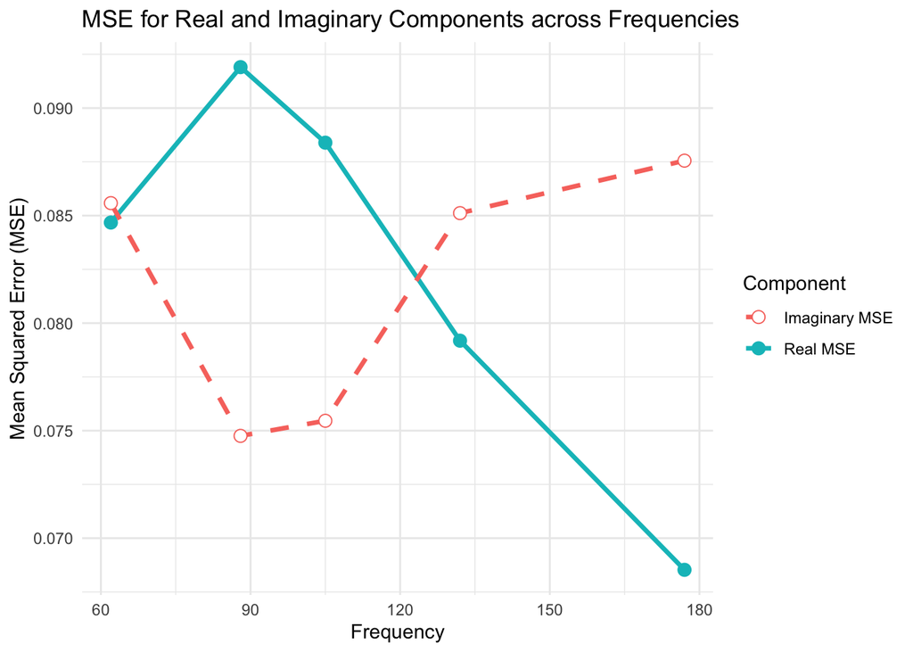

```r
# Load ggplot2 for plotting
library(ggplot2)

# Sample data (assuming the table you showed is stored in a data frame called `results_df`)
# Uncomment the following line if your data is not yet in `results_df`
# results_df <- data.frame(Frequency = c(62, 88, 105, 132, 177), MSE_Real = c(...), MSE_Imag = c(...), R_squared_Real = c(...), R_squared_Imag = c(...))

# Plot MSE values for Real and Imaginary components across frequencies
ggplot(results_df, aes(x = Frequency)) +
  geom_line(aes(y = MSE_Real, color = "Real MSE"), size = 1.2) +
  geom_point(aes(y = MSE_Real, color = "Real MSE"), size = 3) +
  geom_line(aes(y = MSE_Imag, color = "Imaginary MSE"), linetype = "dashed", size = 1.2) +
  geom_point(aes(y = MSE_Imag, color = "Imaginary MSE"), size = 3, shape = 21, fill = "white") +
  labs(title = "MSE for Real and Imaginary Components across Frequencies",
       x = "Frequency",
       y = "Mean Squared Error (MSE)",
       color = "Component") +
  theme_minimal()
```

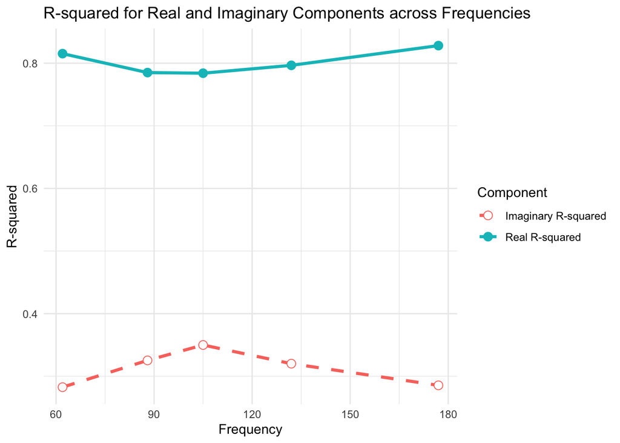

```r
# Plot R-squared values for Real and Imaginary components across frequencies
ggplot(results_df, aes(x = Frequency)) +
  geom_line(aes(y = R_squared_Real, color = "Real R-squared"), size = 1.2) +
  geom_point(aes(y = R_squared_Real, color = "Real R-squared"), size = 3) +
  geom_line(aes(y = R_squared_Imag, color = "Imaginary R-squared"), linetype = "dashed", size = 1.2) +
  geom_point(aes(y = R_squared_Imag, color = "Imaginary R-squared"), size = 3, shape = 21, fill = "white") +
  labs(title = "R-squared for Real and Imaginary Components across Frequencies",
       x = "Frequency",
       y = "R-squared",
       color = "Component") +
  theme_minimal()
```

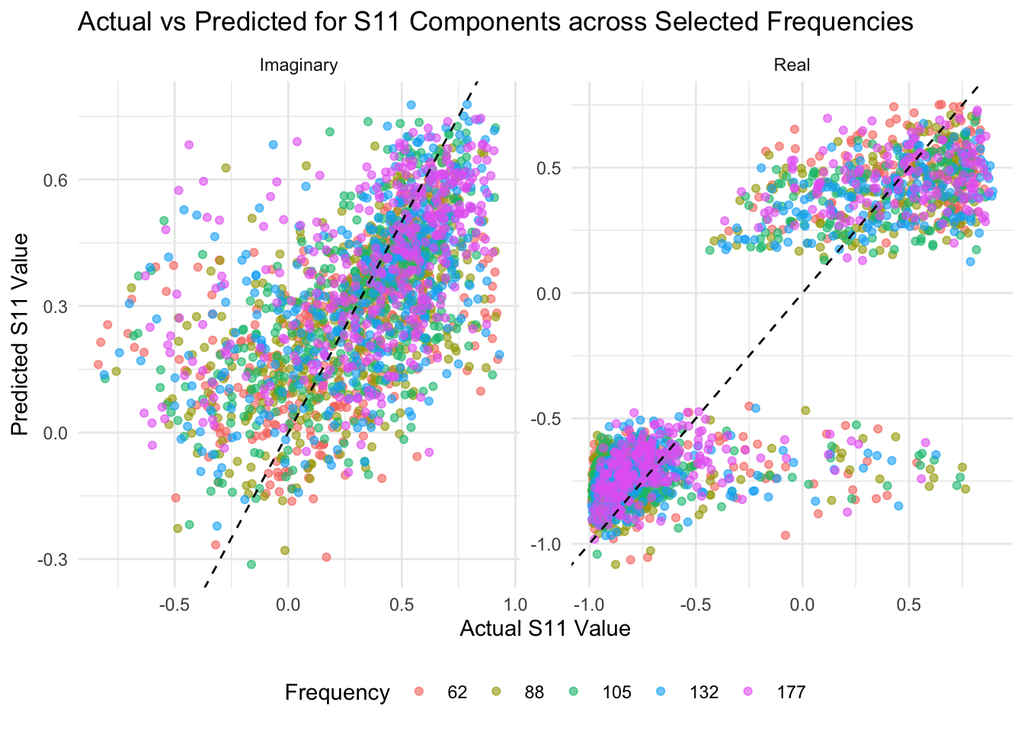

```r
# Load ggplot2 for plotting
library(ggplot2)

# Assuming we have a list of frequencies and their corresponding actual and predicted data
# Replace this with actual data frames for each frequency and component
selected_frequencies <- c(62, 88, 105, 132, 177)
plot_data <- data.frame()  # Empty data frame to store all data for plotting

for (freq in selected_frequencies) {
  # Assuming `real_selected` and `img_selected` contain the actual values,
  # and `predicted_real` and `predicted_img` are the predicted values
  # Replace this with actual values from your models

  # Example actual and predicted data
  real_selected <- as.numeric(real_s11[[freq]])
  img_selected <- as.numeric(img_s11[[freq]])
  predicted_real <- predict(lm(real_selected ~ ., data = input_data))
  predicted_img <- predict(lm(img_selected ~ ., data = input_data))

  # Create data frames for Real and Imaginary components
  real_data <- data.frame(Frequency = freq, Component = "Real",
                          Actual = real_selected, Predicted = predicted_real)
  img_data <- data.frame(Frequency = freq, Component = "Imaginary",
                         Actual = img_selected, Predicted = predicted_img)

  # Combine into one data frame for plotting
  plot_data <- rbind(plot_data, real_data, img_data)
}

# Plot Actual vs Predicted for both Real and Imaginary components across frequencies
ggplot(plot_data, aes(x = Actual, y = Predicted, color = as.factor(Frequency))) +
  geom_point(alpha = 0.6) +
  geom_abline(intercept = 0, slope = 1, linetype = "dashed", color = "black") +
  facet_wrap(~ Component, scales = "free") +
  labs(title = "Actual vs Predicted for S11 Components across Selected Frequencies",
       x = "Actual S11 Value",
       y = "Predicted S11 Value",
       color = "Frequency") +
  theme_minimal() +
  theme(legend.position = "bottom")
```

These plots show that the model provides more accurate predictions for the Real component, while the predictions for the Imaginary component tend to have greater variability and deviation. This suggests that the model has limited explanatory power for the Imaginary component, possibly indicating a need for more complex modeling techniques or additional features to improve prediction accuracy in that component.

## Answers to Research Questions

#### 1) Can we simplify the regression task by focusing on predicting S11 at a few key frequency points?

Yes, by selecting a subset of key frequencies (62, 88, 105, 132, and 177), we reduce the complexity of the regression task while still capturing critical aspects of S11 behavior. These frequencies were chosen because they represent resonance points or points where S11 exhibits significant variation. This approach not only reduces computational load but also allows us to focus on the most informative frequencies for understanding the relationship between design parameters and S11 behavior.

#### 3) What patterns emerge when linear regression is applied to individual frequency points, and do these patterns suggest any broader trends in the design space?

The analysis reveals that the Real component is consistently well-modeled by the linear regression approach across all frequencies, suggesting a strong linear relationship between the geometric parameters and the Real component of S11. In contrast, the Imaginary component shows lower predictive accuracy, indicating that its relationship with the design parameters may be non-linear or influenced by additional factors not captured in the current model. This discrepancy suggests that while the current geometric parameters are sufficient to model the Real component, the Imaginary component may benefit from a more complex model or additional design features to capture broader trends in the design space effectively.

### 3.4. Model Performance and Interpretability (Research Questions Answers)

#### 1) How do PCA and regression models compare in terms of their ability to simplify and predict the antenna’s performance?

PCA was applied to reduce the dimensionality of the design parameter space, successfully identifying principal components that account for most of the variance in the dataset. This analysis helped reveal which parameters most significantly impact the S11 behavior of the antenna, particularly in terms of its real component. Notably, parameters such as the height of the substrate and the radius of the probe were identified as critical factors. The dimensionality reduction provided by PCA not only made the dataset more manageable but also offered insights into the relationship between these geometric features and the antenna’s performance.

When applying regression models to predict S11 at selected frequency points, the models demonstrated strong predictive accuracy for the real component of S11, with adjusted R-squared values ranging from 0.78 to 0.83. However, the models performed less effectively in predicting the imaginary component, with lower R-squared values (approximately 0.26 to 0.35). This discrepancy suggests that while PCA facilitates simplification and highlights key design parameters, the linear regression models lack the complexity needed to capture the non-linear relationships present in the imaginary component’s behavior. In summary, PCA aids in simplifying the data, while regression models effectively predict the real component but struggle with the imaginary component due to its more complex and potentially non-linear nature.

#### 2) What are the potential limitations of these models, and how could they be improved to more accurately represent complex, nonlinear electromagnetic behavior?

Despite their usefulness, both PCA and linear regression models have limitations in capturing the full scope of the antenna’s electromagnetic behavior:

**PCA Limitations:** Although PCA successfully reduces dimensionality and identifies influential features, its linear nature may fail to capture non-linear interactions between design parameters. This limitation is particularly evident in the imaginary component of S11, where complex, non-linear relationships are likely present.

**Regression Model Limitations:** The linear regression models perform well in predicting the real component but exhibit limited predictive power for the imaginary component. This suggests that the relationship between design parameters and the imaginary component may be non-linear, which the linear regression models cannot accurately capture.

To address these limitations, several improvements could be implemented:

**Non-linear Modeling Techniques:** Non-linear modeling techniques, such as kernel-based methods (e.g., Kernel PCA) or machine learning models like decision trees and neural networks, could provide better representation of the complex electromagnetic behavior, particularly for the imaginary component of S11.

**Feature Engineering:** Introducing derived or interaction features could enhance the model’s ability to explain variance in the imaginary component by capturing the interactions between different design parameters.

**Advanced Regression Models:** Exploring more flexible regression approaches, such as polynomial regression or ridge regression, may improve the model’s ability to capture complex relationships within the data, potentially enhancing prediction accuracy for both the real and imaginary components.

## 5. Conclusions and Real-World Implications

This analysis highlights critical insights into antenna design for high-frequency systems:

**Key Parameters for S11 Performance:** PCA identified key parameters, such as the height of the substrate and probe radius, as major influencers of S11 behavior. Prioritizing these parameters in design can streamline optimization, reducing costs and development time.

**Predictive Modeling:** Linear regression models effectively predicted the real component of S11 but struggled with the imaginary component. This suggests that while simpler models can capture certain design aspects, more complex methods are needed for complete accuracy.

**Advanced Techniques for Non-linear Behavior:** The limitations of linear regression imply that future models could benefit from non-linear techniques, like neural networks, to capture complex interactions in S11’s imaginary component.

**Impact on 5G Antenna Design:** These insights can improve 5G antenna design, enabling more efficient, optimized antennas that meet high-performance standards for next-generation communication networks.

## 6. Challenges and Solutions

Throughout the analysis, we encountered several challenges:

**High Dimensionality:** With 201 frequency points, modeling the entire dataset would have been computationally expensive. To address this, selecting key frequencies based on resonance points, allowing us to focus on meaningful patterns while reducing computation time.

**Low Predictability of Imaginary Component:** The Imaginary component’s low R-squared values indicated that it might not be fully captured by linear regression. Although this limitation was noted, we opted to keep the linear model for simplicity and highlight the need for more advanced modeling techniques as a future improvement.

**Model Interpretation:** Interpreting PCA loadings and regression coefficients required careful analysis to ensure meaningful insights. We addressed this by focusing on components with the highest explained variance and summarizing key predictors, such as substrate height and probe radius, that significantly impacted S11 behavior.

## 7. References

This homework assignment includes assistance from ChatGPT for generating ideas, problem-solving approaches, and explanations related to the tasks. I ensured that the final implementation and coding were completed by myself in alignment with the course’s academic integrity guidelines.